# p8106_final

## cart

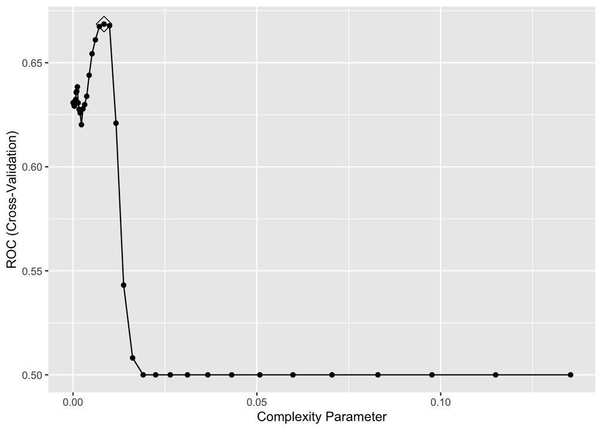

```r
ctrl <- trainControl(method = "cv",
                     summaryFunction = twoClassSummary,
                     classProbs = TRUE)
set.seed(1)
rpart.fit <- train(recovery_bin ~ . ,
                   data = dat,
                   subset = sample,
                   method = "rpart",
                   tuneGrid = data.frame(cp = exp(seq(-10,-2, len = 50))),
                   trControl = ctrl,
                   metric = "ROC")
ggplot(rpart.fit, highlight = TRUE)
```

```r
rpart.fit$bestTune
```

```
##            cp
## 33 0.00843378
```

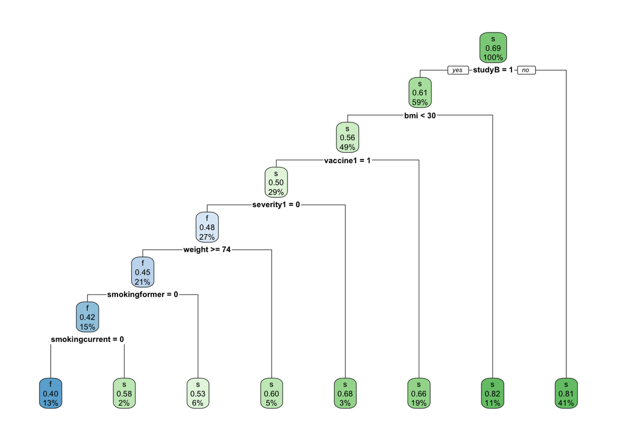

```r
rpart.plot(rpart.fit$finalModel)
```

The optimal value of cp is 0.00843378, which is the value of the complexity parameter that results in the best performance of the model. Here, the cp controls the complexity of the tree, with smaller values of cp resulting in larger trees and larger values of cp resulting in smaller trees with fewer splits.

From the plot, we see that the tree with size of 7 has the highest ROC.

## cit

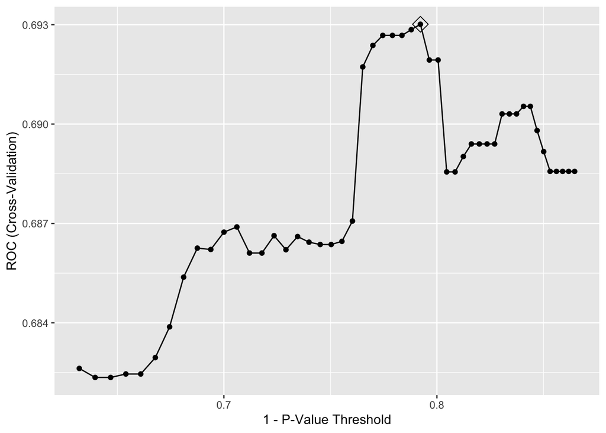

```r
set.seed(1)
ctree.fit <- train(recovery_bin ~ . ,
                   dat,
                   subset = sample,
                   method = "ctree",
                   tuneGrid = data.frame(mincriterion = 1-exp(seq(-2, -1, length = 50))),
                   metric = "ROC",
                   trControl = ctrl)
ggplot(ctree.fit, highlight = TRUE)
```

[figure not shown]

```r
plot(ctree.fit$finalModel)
```

```r
ctree.fit$bestTune
```

```
##    mincriterion
## 29    0.7922518
```

## compare two trees

```r
summary(resamples(list(rpart.fit, ctree.fit)))
```

```
##
## Call:
## summary.resamples(object = resamples(list(rpart.fit, ctree.fit)))
##
## Models: Model1, Model2
## Number of resamples: 10
##
## ROC
##             Min.   1st Qu.    Median      Mean   3rd Qu.      Max. NA's
## Model1 0.5879096 0.6473394 0.6800718 0.6685811 0.6942277 0.7098862    0
## Model2 0.6083583 0.6793764 0.7028633 0.6930137 0.7173295 0.7319855    0
##
## Sens
##             Min.   1st Qu.    Median      Mean   3rd Qu.      Max. NA's
## Model1 0.1590909 0.2758621 0.2873563 0.2897858 0.3019527 0.4204545    0
## Model2 0.2272727 0.2758621 0.2972179 0.3390413 0.3908046 0.5227273    0
##
## Spec
##             Min.   1st Qu.    Median      Mean   3rd Qu.      Max. NA's
## Model1 0.8578680 0.8795890 0.8883249 0.8889555 0.9022843 0.9137056    0
## Model2 0.7969543 0.8306607 0.8886197 0.8702046 0.9010152 0.9187817    0
```

Since ctree.fit model has larger ROC, it’s a better classification tree compared to the rpart.fit.